# ExtraaLearn: Lead Intelligence System

## Practical Data Science | Elective Project

ExtraaLearn is an early-stage EdTech startup that sells technology programs to students and working professionals. As lead volume grows, so does the pressure to work the pipeline efficiently. The sales team can't chase everyone, so the question becomes: who is actually worth calling?

This project builds a Lead Intelligence System to answer that question:

- Predict which leads are most likely to convert to paying customers
- Identify what separates high-probability leads from low ones
- Give the sales team a prioritized list of who to contact first

The full workflow runs from data understanding through EDA, preprocessing, modeling, explainability, lead scoring, and recommendations.

## Contents

1. Business Problem Overview
2. Setup & Library Imports
3. Data Understanding & Audit
4. Exploratory Data Analysis (EDA)
5. Preprocessing & Feature Engineering
6. Modeling
7. Model Evaluation
8. Feature Importance & Explainability
9. Lead Scoring & Priority Tiers
10. Recommendations
11. Conclusions & Executive Summary

Appendix: Data Dictionary

## Business Problem Overview

### Industry Context

EdTech has grown fast, and competition for the same pool of learners has grown with it. Companies like ExtraaLearn can't rely on brand recognition or massive ad budgets to drive growth. Being efficient with how they allocate sales resources isn't optional -- it's the whole game.

### The Problem

ExtraaLearn pulls in leads from multiple sources: the website, mobile app, social media, and referrals. The problem is there's no reliable signal for which leads are worth prioritizing. Treating every lead the same wastes the team's time on low-probability contacts while high-probability leads cool off waiting.

The central question: which leads are most likely to convert, and what do they look like?

### Objective

1. **Predict** which leads are most likely to become paying customers
2. **Identify** the features that most influence conversion
3. **Profile** what a high-conversion lead looks like
4. **Recommend** how sales and marketing should adjust their approach

### Solution Approach

Supervised binary classification on the ExtraaLearn lead dataset. Target variable is `status` (1 = converted, 0 = not converted).

| Phase | Focus |
| --- | --- |
| Data Understanding | Structure, data types, quality checks, class split |
| EDA | Conversion patterns by segment, engagement behavior, channel analysis |
| Preprocessing | Encoding, scaling, outlier treatment, feature engineering |
| Modeling | Logistic Regression through ensemble models with cross validation |
| Evaluation | Precision, Recall, F1, ROC-AUC, PR-AUC |
| Explainability | SHAP values, feature importance, business translation |
| Lead Scoring | Probability-based tiers with action recommendations |

**Evaluation note:** With a ~30% conversion rate, accuracy is a misleading metric. The final model is evaluated on ROC-AUC and PR-AUC, and output includes a scored lead list broken into priority tiers.

## Setup & Library Imports

This cell loads the libraries needed to run the analysis. Imports are grouped by function so each block is easy to scan.

```python
# Setup & Library Imports

# Core Libraries
import numpy as np
import pandas as pd
import warnings
warnings.filterwarnings('ignore')

# Visualization Libraries
import matplotlib.pyplot as plt
import matplotlib.ticker as mtick
import seaborn as sns

# Display settings
pd.set_option('display.max_columns', None)
pd.set_option('display.float_format', '{:.2f}'.format)
plt.rcParams['figure.figsize'] = (10, 5)
plt.rcParams['figure.dpi'] = 150
sns.set_theme(style='whitegrid', palette='muted')

# Sklearn: Preprocessing & Pipeline Libraries
from sklearn.model_selection import train_test_split, GridSearchCV, StratifiedKFold, cross_val_score, RandomizedSearchCV
from sklearn.preprocessing import StandardScaler, OneHotEncoder, LabelEncoder, MinMaxScaler
from sklearn.compose import ColumnTransformer
from sklearn.pipeline import Pipeline
from sklearn.utils.class_weight import compute_sample_weight

# Sklearn: Models
from sklearn.linear_model import LogisticRegression
from sklearn.tree import DecisionTreeClassifier
from sklearn.ensemble import RandomForestClassifier, GradientBoostingClassifier

# Sklearn: Metrics
from sklearn.metrics import (
    classification_report, confusion_matrix, ConfusionMatrixDisplay,
    roc_auc_score, roc_curve, precision_recall_curve, average_precision_score,
    f1_score, precision_score, recall_score
)

# Model Tuning
from xgboost import XGBClassifier

# Explainability
import shap

# Deep Learning
import torch
import torch.nn as nn
from torch.utils.data import DataLoader, TensorDataset

# Utilities
from IPython.display import display, Markdown
import joblib
import os

print(f"numpy      {np.__version__}")
print(f"pandas     {pd.__version__}")
print(f"sklearn    {__import__('sklearn').__version__}")
print(f"shap       {shap.__version__}")
print(f"torch      {torch.__version__} | MPS available: {torch.backends.mps.is_available()}")
print("Environment ready.")
```

```
numpy      2.4.4
pandas     3.0.1
sklearn    1.8.0
shap       0.51.0
torch      2.12.0 | MPS available: True
Environment ready.
```

#### Observation

All libraries loaded successfully using the versions current at the time this project was built. Newer versions may be available in the future.

*Note: This project runs on an Apple Silicon MacBook Pro. Because TensorFlow does not currently support Python 3.14, PyTorch is used for the deep learning section. PyTorch also provides native GPU acceleration on Apple Silicon through Metal Performance Shaders (MPS).*

## Data Understanding & Audit

Before doing any analysis, it helps to get a clear picture of what the data actually looks like, dimensions, column types, completeness, and basic distributions. This section covers those fundamentals and flags anything that needs to be addressed before moving into EDA.

```python
# Load Data
# Read the CSV into a DataFrame -- all subsequent analysis runs from this object
data = pd.read_csv('/Users/robshypitka/Documents/MIT/Elective Project/Elective Project Potential Customer Prediction/ExtraaLearn.csv')
data_raw = data.copy()

print('Dataset Preview (First 5 Rows)')
display(data.head())

# Shape & Structure
# Quick check on dimensions and column data types before going any deeper
print(f'\nDataset contains {data.shape[0]} rows and {data.shape[1]} columns.')
print('\nColumn Types & Non-Null Counts')
print()
data.info()

# Missing Values
# Confirming data completeness -- any nulls here would require a treatment strategy
null_summary = pd.DataFrame(data.isnull().sum(), columns=['Missing Values'])
null_summary['% Missing'] = (null_summary['Missing Values'] / len(data) * 100).round(2)
print('\nMissing Value Check')
display(null_summary)

# Duplicates
print(f'Duplicate rows: {data.duplicated().sum()}')

# Summary Statistics
# Splitting numeric and categorical: combined describe() tables are hard to read
print('\nNumeric Features: Summary Statistics')
display(data.describe().T)

print('\nCategorical Features: Value Counts')
display(data.describe(include='object').T)
```

```
Dataset Preview (First 5 Rows)
```

|  | ID | age | current_occupation | first_interaction | profile_completed | website_visits | time_spent_on_website | page_views_per_visit | last_activity | print_media_type1 | print_media_type2 | digital_media | educational_channels | referral | status |
| --- | --- | --- | --- | --- | --- | --- | --- | --- | --- | --- | --- | --- | --- | --- | --- |
| 0 | EXT001 | 57 | Unemployed | Website | High | 7 | 1639 | 1.86 | Website Activity | Yes | No | Yes | No | No | 1 |
| 1 | EXT002 | 56 | Professional | Mobile App | Medium | 2 | 83 | 0.32 | Website Activity | No | No | No | Yes | No | 0 |
| 2 | EXT003 | 52 | Professional | Website | Medium | 3 | 330 | 0.07 | Website Activity | No | No | Yes | No | No | 0 |
| 3 | EXT004 | 53 | Unemployed | Website | High | 4 | 464 | 2.06 | Website Activity | No | No | No | No | No | 1 |
| 4 | EXT005 | 23 | Student | Website | High | 4 | 600 | 16.91 | Email Activity | No | No | No | No | No | 0 |

```
Dataset contains 4612 rows and 15 columns.

Column Types & Non-Null Counts

<class 'pandas.DataFrame'>
RangeIndex: 4612 entries, 0 to 4611
Data columns (total 15 columns):
 #   Column                 Non-Null Count  Dtype
---  ------                 --------------  -----
 0   ID                     4612 non-null   str
 1   age                    4612 non-null   int64
 2   current_occupation     4612 non-null   str
 3   first_interaction      4612 non-null   str
 4   profile_completed      4612 non-null   str
 5   website_visits         4612 non-null   int64
 6   time_spent_on_website  4612 non-null   int64
 7   page_views_per_visit   4612 non-null   float64
 8   last_activity          4612 non-null   str
 9   print_media_type1      4612 non-null   str
 10  print_media_type2      4612 non-null   str
 11  digital_media          4612 non-null   str
 12  educational_channels   4612 non-null   str
 13  referral               4612 non-null   str
 14  status                 4612 non-null   int64
dtypes: float64(1), int64(4), str(10)
memory usage: 791.8 KB

Missing Value Check
```

|  | Missing Values | % Missing |
| --- | --- | --- |
| ID | 0 | 0.00 |
| age | 0 | 0.00 |
| current_occupation | 0 | 0.00 |
| first_interaction | 0 | 0.00 |
| profile_completed | 0 | 0.00 |
| website_visits | 0 | 0.00 |
| time_spent_on_website | 0 | 0.00 |
| page_views_per_visit | 0 | 0.00 |
| last_activity | 0 | 0.00 |
| print_media_type1 | 0 | 0.00 |
| print_media_type2 | 0 | 0.00 |
| digital_media | 0 | 0.00 |
| educational_channels | 0 | 0.00 |
| referral | 0 | 0.00 |
| status | 0 | 0.00 |

```
Duplicate rows: 0

Numeric Features: Summary Statistics
```

|  | count | mean | std | min | 25% | 50% | 75% | max |
| --- | --- | --- | --- | --- | --- | --- | --- | --- |
| age | 4612.00 | 46.20 | 13.16 | 18.00 | 36.00 | 51.00 | 57.00 | 63.00 |
| website_visits | 4612.00 | 3.57 | 2.83 | 0.00 | 2.00 | 3.00 | 5.00 | 30.00 |
| time_spent_on_website | 4612.00 | 724.01 | 743.83 | 0.00 | 148.75 | 376.00 | 1336.75 | 2537.00 |
| page_views_per_visit | 4612.00 | 3.03 | 1.97 | 0.00 | 2.08 | 2.79 | 3.76 | 18.43 |
| status | 4612.00 | 0.30 | 0.46 | 0.00 | 0.00 | 0.00 | 1.00 | 1.00 |

```
Categorical Features: Value Counts
```

|  | count | unique | top | freq |
| --- | --- | --- | --- | --- |
| ID | 4612 | 4612 | EXT001 | 1 |
| current_occupation | 4612 | 3 | Professional | 2616 |
| first_interaction | 4612 | 2 | Website | 2542 |
| profile_completed | 4612 | 3 | High | 2264 |
| last_activity | 4612 | 3 | Email Activity | 2278 |
| print_media_type1 | 4612 | 2 | No | 4115 |
| print_media_type2 | 4612 | 2 | No | 4379 |
| digital_media | 4612 | 2 | No | 4085 |
| educational_channels | 4612 | 2 | No | 3907 |
| referral | 4612 | 2 | No | 4519 |

#### Observations

Clean data with nothing major to deal with upfront:

A few things to flag for preprocessing:

- `time_spent_on_website` has a gap between mean (724) and median (376) -- right skew, likely some high-engagement leads pulling it up
- `website_visits` and `page_views_per_visit` show the same pattern -- median well below the mean, high max values
- These three are worth checking for outliers and possible transformation

`ID` is just a unique identifier with no predictive value -- will be dropped before modeling.

## Exploratory Data Analysis (EDA)

With the data confirmed clean, the focus shifts to understanding what is actually in it. EDA here is not just a formality, it is where the real business questions start to get answered.

The analysis is broken into two parts:

**Univariate Analysis** looks at each feature on its own. For numeric features this means understanding the shape of the distribution, the spread, and any obvious outliers. For categorical features it means understanding how the data is distributed across categories. This step builds the foundation for every decision made in preprocessing and modeling.

**Multivariate Analysis** looks at relationships between features and the target variable (`status`). The goal is to identify which features show the strongest signal for conversion, those findings directly inform feature selection and model interpretation later on.

The EDA is structured as follows:

1. Target Distribution: class balance check for our target variable, `status`
2. Univariate Analysis: Numeric Features
3. Univariate Analysis: Categorical Features
4. Correlation Analysis: Numeric Features
5. Multivariate Analysis: Conversion Rates by Category
6. Multivariate Analysis: Numeric Features vs. Conversion

### Univariate Analysis

#### Target Distribution

```
Target Variable Distribution
```

|  | Count | % Share |
| --- | --- | --- |
| Not Converted (0) | 3235 | 70.14 |
| Converted (1) | 1377 | 29.86 |

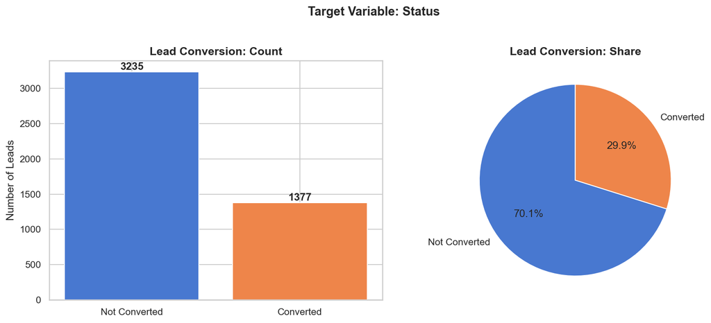

```python
# Target Distribution
# Before anything else, understand how balanced the target variable is.
# A heavily imbalanced target means accuracy is a misleading metric, a model
# that predicts "not converted" every time would still score 70% accuracy here.

# Count and percentage breakdown of the target
target_counts = data['status'].value_counts()
target_pct = data['status'].value_counts(normalize=True) * 100

target_summary = pd.DataFrame({
    'Count': target_counts,
    '% Share': target_pct.round(2)
})
target_summary.index = ['Not Converted (0)', 'Converted (1)']

print('Target Variable Distribution')
display(target_summary)

# Visualize the class split
fig, axes = plt.subplots(1, 2, figsize=(12, 5))

# Bar chart -- raw counts
axes[0].bar(
    ['Not Converted', 'Converted'],
    target_counts.values,
    color=sns.color_palette('muted')[0:2]
)
axes[0].set_title('Lead Conversion: Count', fontsize=13, fontweight='bold')
axes[0].set_ylabel('Number of Leads')
for i, v in enumerate(target_counts.values):
    axes[0].text(i, v + 30, str(v), ha='center', fontweight='bold')

# Pie chart -- proportions
axes[1].pie(
    target_counts.values,
    labels=['Not Converted', 'Converted'],
    autopct='%1.1f%%',
    colors=sns.color_palette('muted')[0:2],
    startangle=90
)
axes[1].set_title('Lead Conversion: Share', fontsize=13, fontweight='bold')

plt.suptitle('Target Variable: Status', fontsize=14, fontweight='bold', y=1.02)
plt.tight_layout()
plt.show()
```

#### Observations

The dataset is imbalanced with roughly 70% of leads not converting and 30% converting. This is expected for a lead funnel, most leads never become customers.

This split has direct implications for modeling:

- Accuracy alone is not a useful metric here
- Evaluation will focus on Precision, Recall, F1, and ROC-AUC
- All classifiers will use `class_weight='balanced'` to avoid the model simply predicting the majority class

This imbalance is moderate enough that resampling techniques like SMOTE are not required, but it will be monitored throughout.

#### Numeric Features

```python
# Numeric Features: Distributions & Outliers
# Visualize the distribution of numeric features to understand their shape and identify outliers.
num_cols = data.select_dtypes(include=['float64', 'int64']).columns.drop('status')

# Boxplot stacked above histogram; mean (green dashed) and median (black solid) marked
def histogram_boxplot(data, feature, figsize=(12, 7), kde=False, bins=None):
    fig, (ax_box, ax_hist) = plt.subplots(
        nrows=2,
        sharex=True,
        gridspec_kw={"height_ratios": (0.25, 0.75)},
        figsize=figsize,
    )
    sns.boxplot(data=data, x=feature, ax=ax_box, showmeans=True, color="violet")

    hist_kwargs = {'data': data, 'x': feature, 'kde': kde, 'ax': ax_hist, 'color': 'steelblue'}
    if bins:
        hist_kwargs['bins'] = bins
    sns.histplot(**hist_kwargs)

    ax_hist.axvline(data[feature].mean(), color="green", linestyle="--")   # mean
    ax_hist.axvline(data[feature].median(), color="black", linestyle="-")  # median
    ax_box.set_title(
        f'{feature.replace("_", " ").title()} - Distribution & Outliers',
        fontsize=13, fontweight='bold'
    )
    plt.tight_layout()
    plt.show()
```

Age

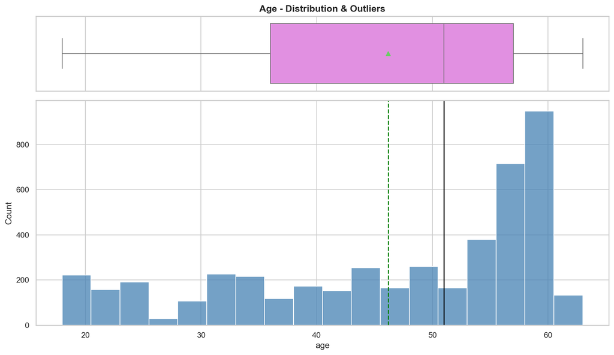

Website Visits

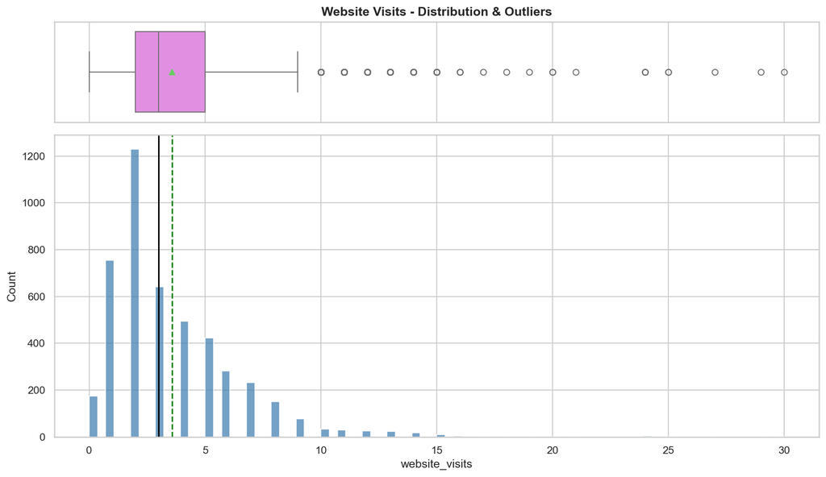

Time Spent On Website

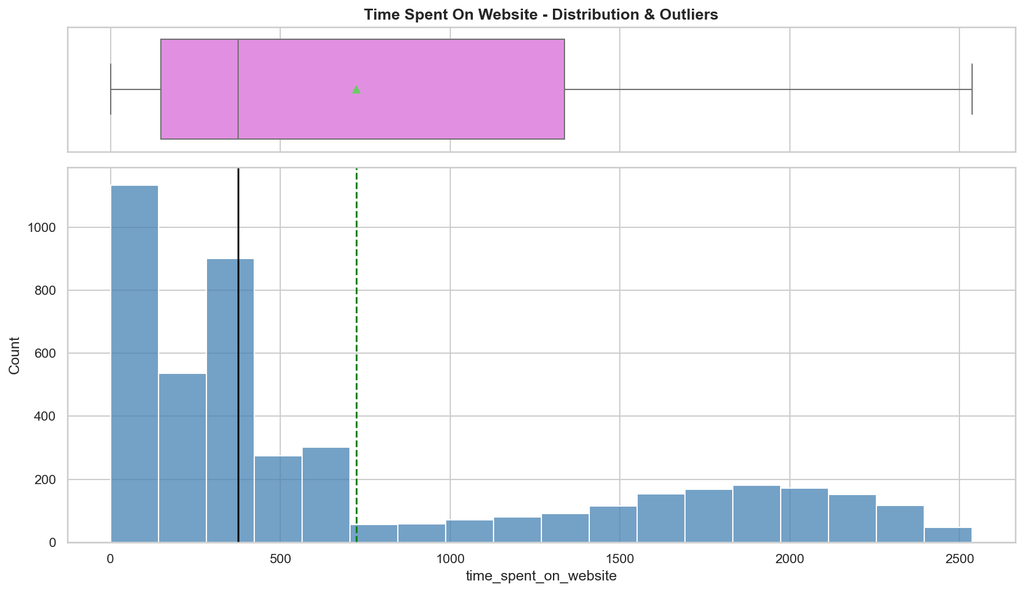

Page Views Per Visit

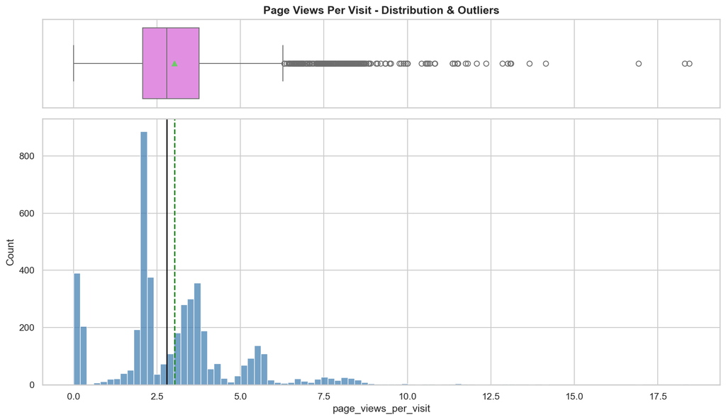

```python
# Loop through each numeric column
for num in num_cols:
    display(Markdown(f'#### {num.replace("_", " ").title()}'))
    histogram_boxplot(data, num)
```

#### Observations

`age` is moderately left-skewed -- median (51) above the mean (46.2), with most leads in the 36-57 range. No notable outliers.

`website_visits`, `time_spent_on_website`, and `page_views_per_visit` are all right-skewed. A small number of high-engagement leads pull the mean above the median in each. Both `website_visits` and `page_views_per_visit` have visible outlier points beyond the whiskers. `time_spent` has a wide spread but no extreme outliers by eye.

These three will get an IQR outlier check in preprocessing. Whether they need log transformation depends on what skewness looks like after clipping -- will check there.

#### Categorical Features

```python
# List all of the categorical features
cat_cols = [
    'current_occupation', 'first_interaction', 'profile_completed',
    'last_activity', 'print_media_type1', 'print_media_type2',
    'digital_media', 'educational_channels', 'referral'
]

def bar_plot(data, feature, figsize=(12, 7)):
    # stat='percent' normalizes the y-axis to show share of total
    plt.figure(figsize=figsize)
    ax = sns.countplot(data=data, x=feature, stat='percent')
    for p in ax.patches:
        ax.annotate(
            f'{p.get_height():.1f}%',
            (p.get_x() + p.get_width() / 2., p.get_height()),
            ha='center', va='bottom', fontsize=10, fontweight='bold'
        )
    plt.title(f'{feature.replace("_", " ").title()} - Distribution', fontsize=13, fontweight='bold')
    plt.ylabel('Percentage')
    plt.xlabel(feature.replace('_', ' ').title())
    plt.xticks(rotation=45, ha='right')
    plt.show()
```

Current Occupation

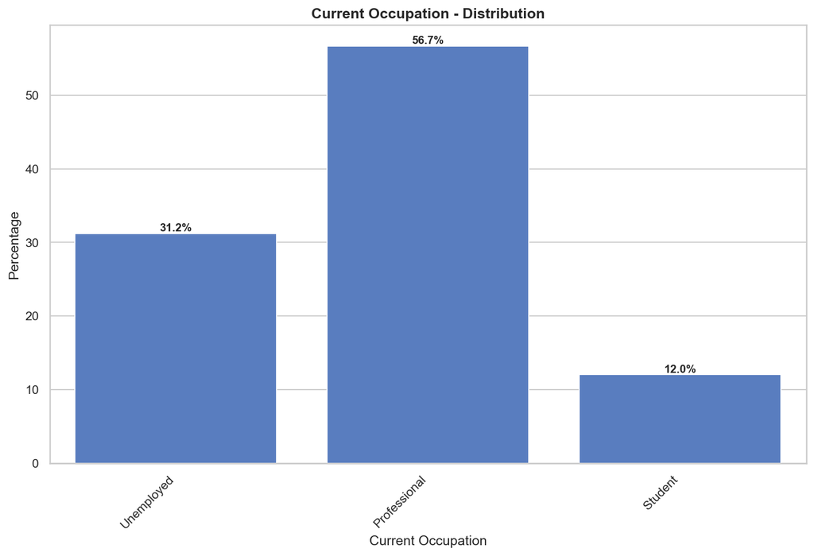

First Interaction

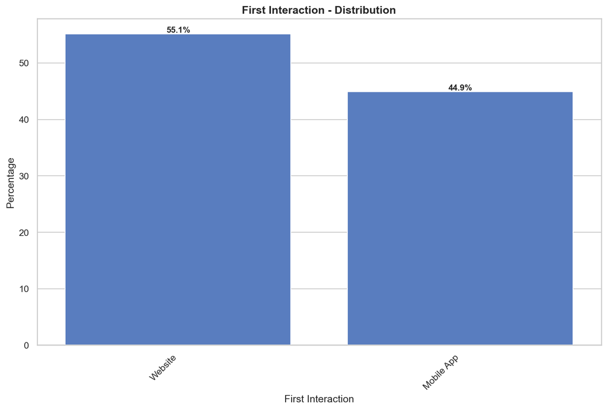

Profile Completed

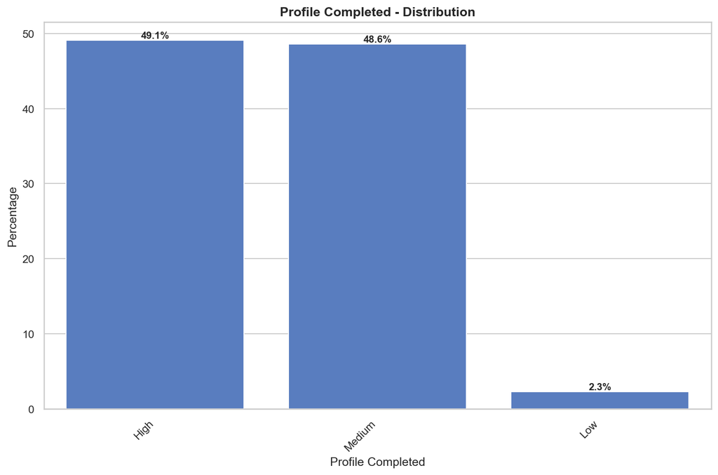

Last Activity

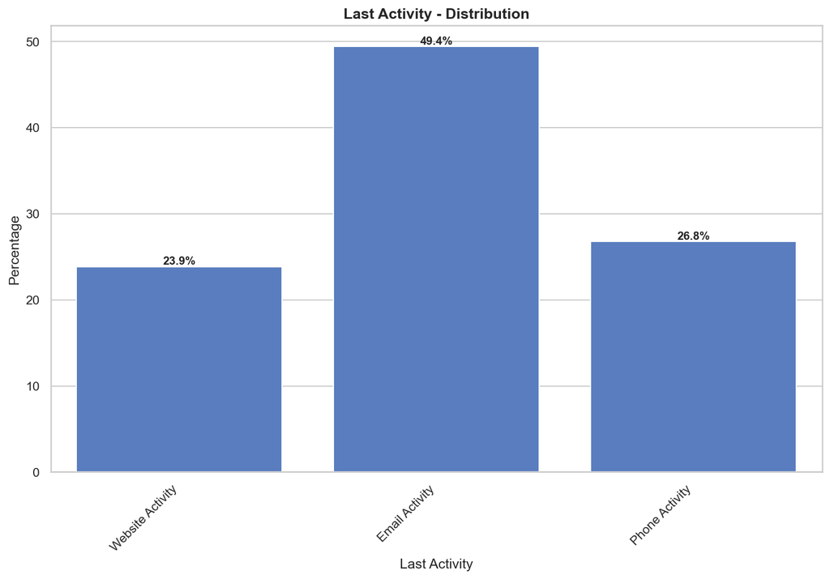

Print Media Type1

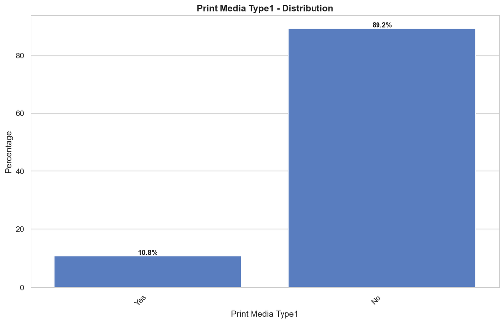

Print Media Type2

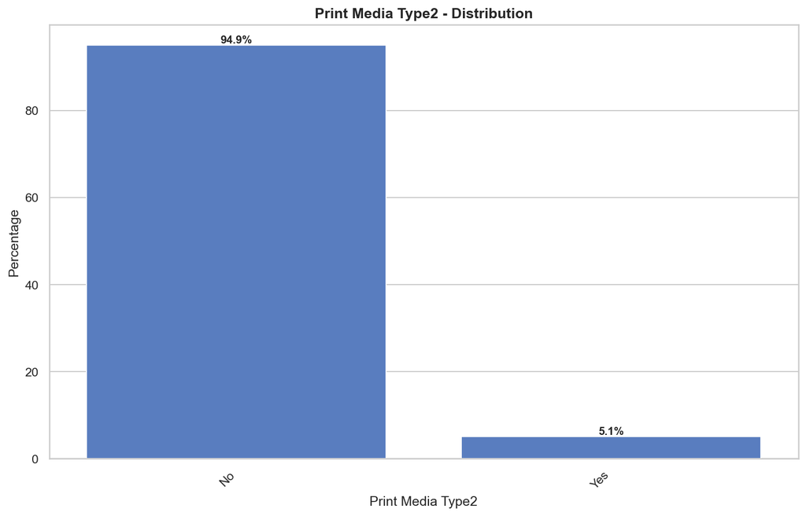

Digital Media

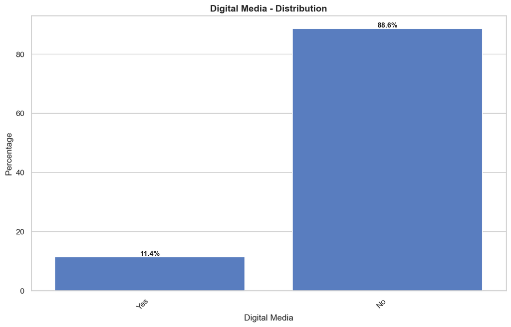

Educational Channels

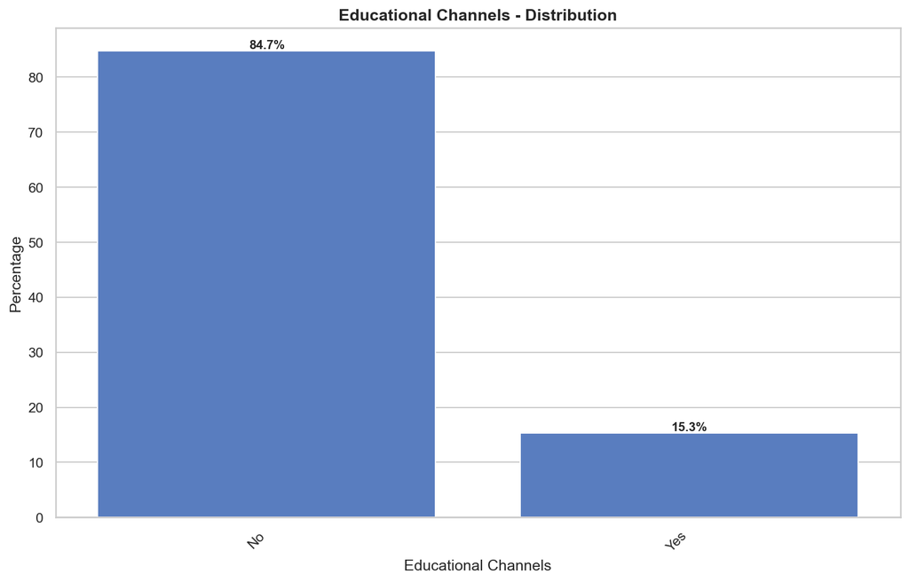

Referral

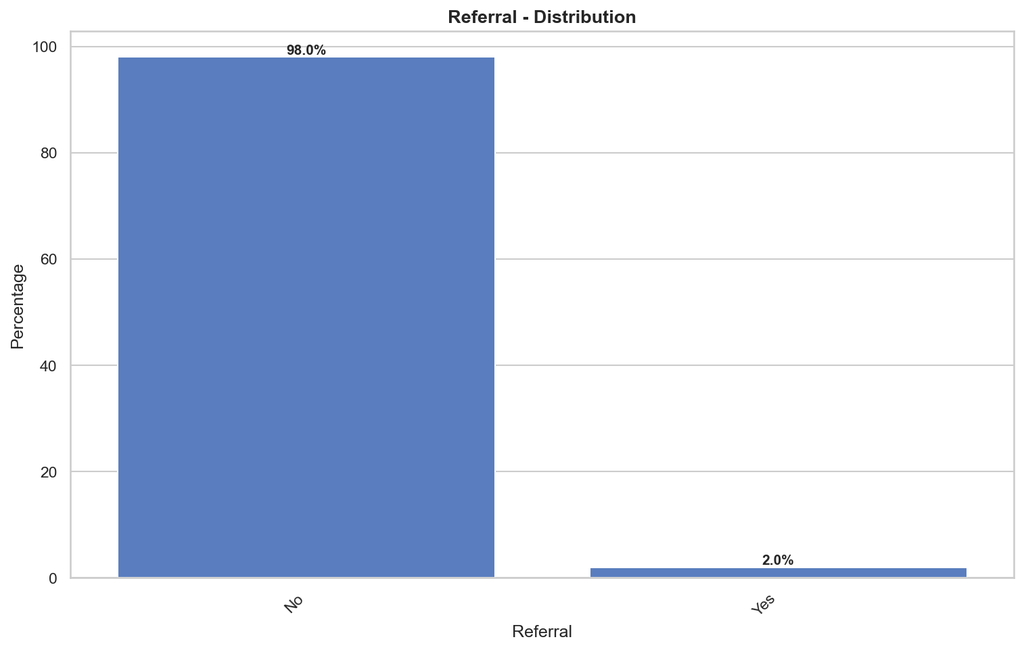

```python
# Create bar plots
for col in cat_cols:
    display(Markdown(f'#### {col.replace("_", " ").title()}'))
    bar_plot(data, col)
```

#### Observations

**Current Occupation:** The majority of leads (57%) identify as professionals. Unemployed leads make up the second largest group, followed by students. Together, unemployed and student leads account for less than half the total, meaning ExtraaLearn's audience skews heavily toward working adults.

**First Interaction:** Lead entry is fairly balanced between channels, with the website accounting for roughly 55% of first interactions and the mobile app making up the remaining 45%. Neither channel dominates significantly.

**Profile Completion:** The vast majority of leads have at least a partially completed profile. High and Medium completion are nearly equal at approximately 49% each, with Low completion representing only about 2% of leads. This suggests most leads are genuinely engaged enough to complete their profile.

**Last Activity:** Email activity accounts for nearly half (49%) of the most recent lead interactions, with phone and website activity at 27% and 24% respectively. Email is clearly the dominant touchpoint.

**Key Takeaway:** Most leads come in through owned channels -- the website and mobile app -- with paid and earned media touching a small fraction of the total. That puts more weight on behavioral signals like time on site, profile completion, and page views as potential predictors, since channel attribution alone won't tell the whole story. The multivariate analysis will test this.

### Correlation Analysis

#### Numeric Features

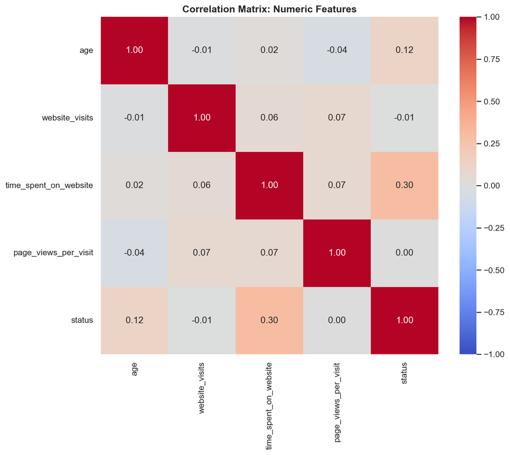

```python
# Correlation on original numeric features only -- engineered features evaluated separately
corr_matrix = data[num_cols.tolist() + ['status']].corr()

plt.figure(figsize=(10, 8))
sns.heatmap(corr_matrix,
            annot=True,
            fmt='.2f',
            cmap='coolwarm',
            vmin=-1,
            vmax=1,
            square=True
)
plt.title('Correlation Matrix: Numeric Features', fontsize=13, fontweight='bold')
plt.show()
```

#### Observations

None of the numeric features have a strong linear relationship with `status`. `time_spent_on_website` comes in highest at +0.30, with `age` at +0.12. Meaningful signal, but neither clears the +/- 0.50 threshold typically associated with strong linear correlation.

Feature-to-feature correlations are all at 0.10 or below, which means these features aren't measuring the same thing and multicollinearity isn't a concern for Logistic Regression.

Low linear correlation doesn't mean low predictive value. The relationship between engagement and conversion is likely non-linear -- a lead spending 2,000 minutes on the site behaves very differently from one spending 50, but that gap won't show up cleanly in a Pearson correlation. That's exactly the kind of pattern tree-based models are built to find.

*Note: This heatmap covers the original numeric features only. Engineered features and encoded categorical columns are evaluated separately.*

### Multivariate Analysis

#### Conversion Rates by Category

```python
# Create a function to look at categorical features against the target variable
def conversion_rate_plot(data, feature, figsize=(12,7)):
    plt.figure(figsize=figsize)

    # Calculate conversion rates
    conversion_rates = data.groupby(feature)['status'].mean().reset_index()

    # Bar plot of conversion rates
    ax = sns.barplot(data=conversion_rates, x=feature, y='status', palette='muted')

    # Add percentage labels on top of each bar
    for p in ax.patches:
        ax.annotate(
            f'{p.get_height() * 100:.1f}%',
            (p.get_x() + p.get_width() / 2., p.get_height()),
            ha='center', va='bottom', fontsize=10, fontweight='bold'
        )

    plt.title(f'Conversion Rate by {feature.replace("_", " ").title()}', fontsize=13, fontweight='bold')
    plt.ylabel('Conversion Rate (%)')
    plt.xlabel(feature.replace('_', ' ').title())
    plt.xticks(rotation=45, ha='right')
    plt.ylim(0, 1)
    plt.gca().yaxis.set_major_formatter(mtick.PercentFormatter(1.0))
    plt.tight_layout()
    plt.show()
```

Current Occupation

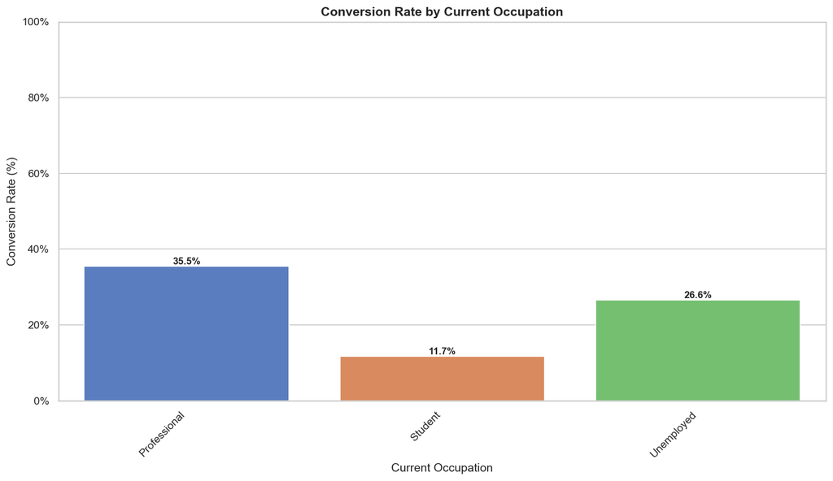

First Interaction

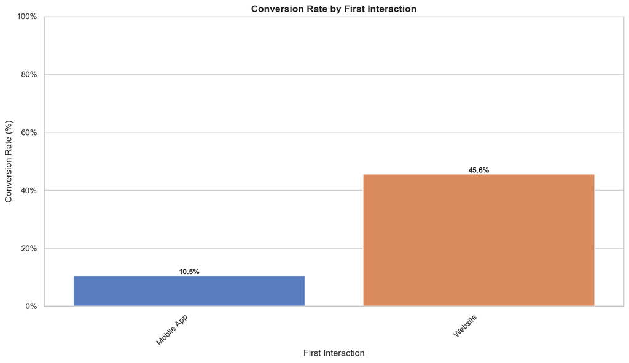

Profile Completed

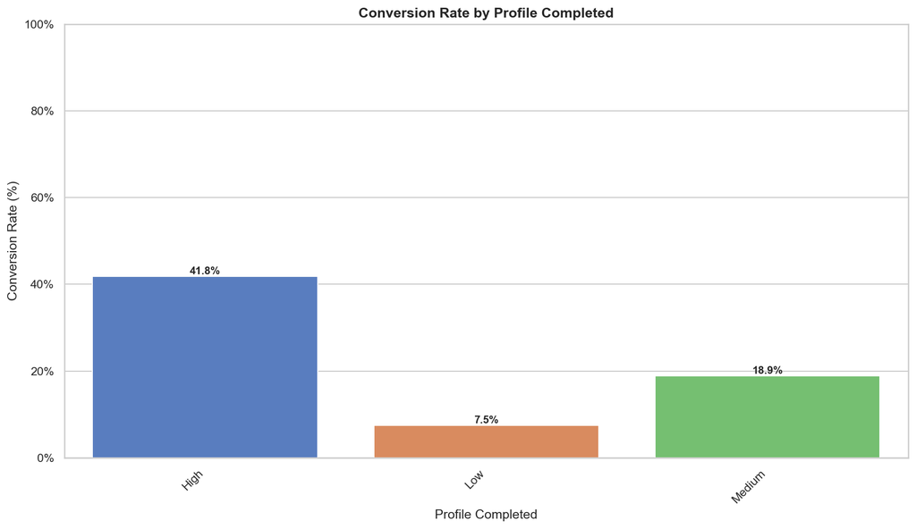

Last Activity

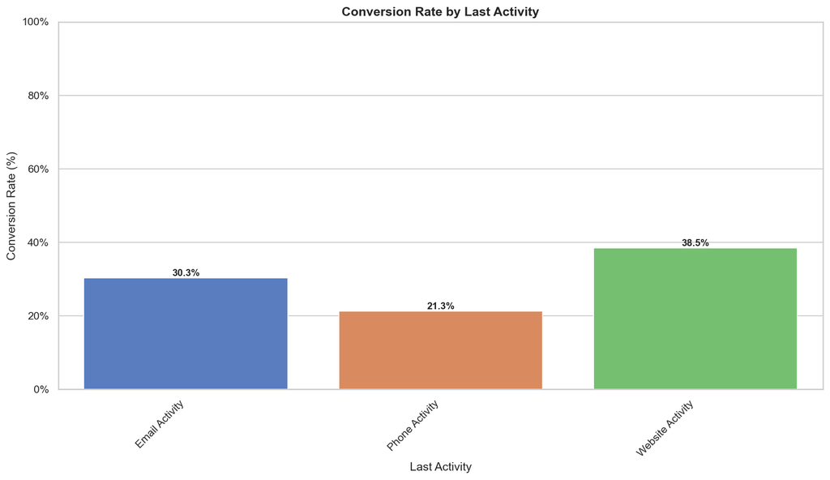

Print Media Type1

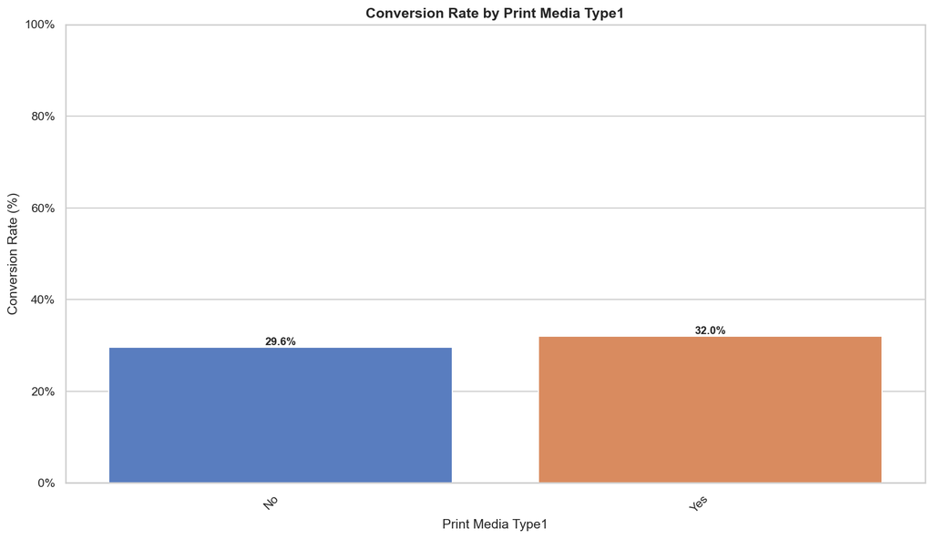

Print Media Type2

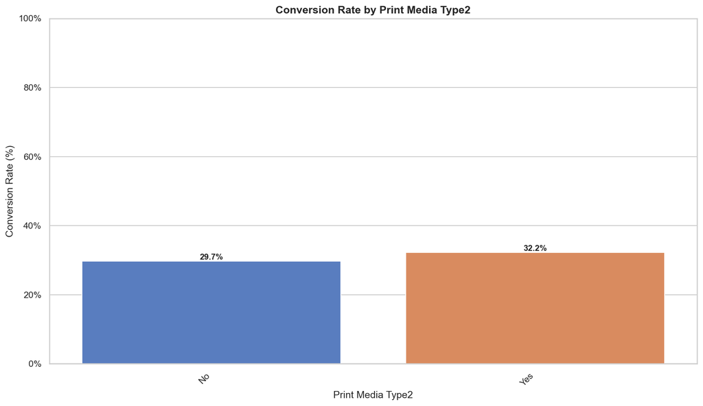

Digital Media

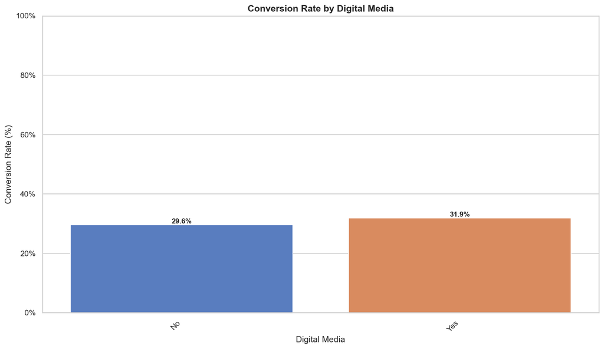

Educational Channels

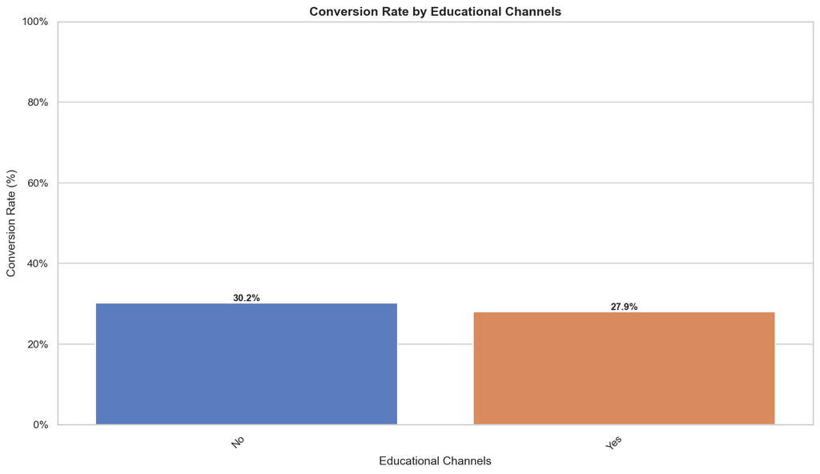

Referral

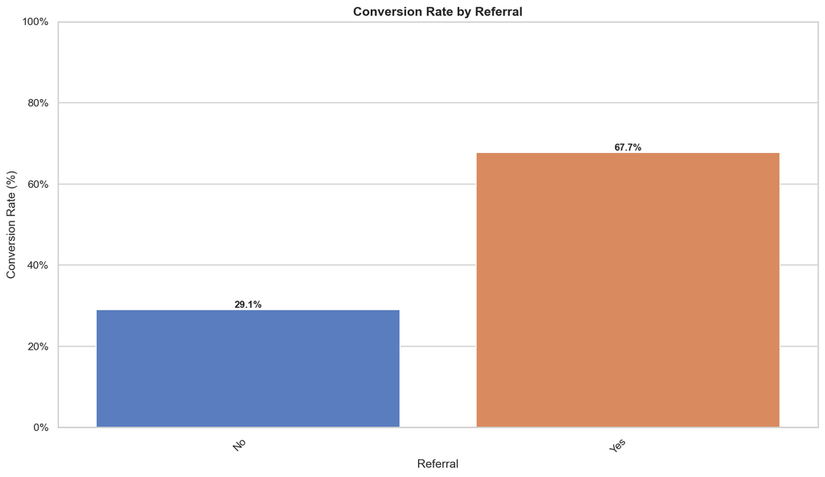

```python
# Create bar plots
for col in cat_cols:
    display(Markdown(f'#### {col.replace("_", " ").title()}'))
    conversion_rate_plot(data, col)
```

#### Observations

**Current Occupation:** Professionals have the highest conversion rate at 35.5%, followed by Unemployed at 26.6% and Students at 11.7%. Professionals convert at roughly 3x the rate of students, which likely reflects their financial position and motivation to invest in career development.

**First Interaction:** Leads whose first interaction was through the website convert at 45.6% compared to just 10.5% for the mobile app. This is one of the stronger signals in the dataset -- the channel of first contact appears to matter significantly.

**Profile Completion:** Conversion rates increase consistently with profile completion. High completion leads convert at 41.8%, Medium at 18.9%, and Low at 7.5%. Leads who invest more time completing their profile appear more committed to following through.

**Last Activity:** Website activity leads to the highest conversion rate at 38.5%, followed by email at 30.3% and phone at 21.3%. Active engagement with the website as the most recent touchpoint is a positive signal for conversion.

**Media Exposure:** Leads exposed to newspaper or magazine ads convert at roughly equal rates to each other. The same is true for digital media and educational channels. However, given that fewer than 15% of leads were reached through any of these channels, the impact on overall conversion volume is limited.

**Referral:** Referred leads convert at the highest rate of any category at 67.7%. While referrals make up only about 2% of all leads, the quality of those leads is clearly superior.

**Key Takeaway:** The strongest signals here are `first_interaction`, `profile_completed`, and `referral`. Professionals who came in through the website with a completed profile convert at dramatically higher rates. Referrals stand out at 67.7% -- small volume, but worth flagging as the highest-quality segment in the dataset.

With a base rate of ~30%, the numeric analysis and model will work out what behavioral patterns separate converters from everyone else.

#### Numeric Features vs. Conversion

```python
# Function to plot a boxplot for converted vs non-converted leads for numeric features

def boxplot_by_status(data, feature, figsize=(12, 7)):
    plt.figure(figsize=figsize)
    sns.boxplot(data = data,
                x = 'status',
                y = feature,
                hue='status',
                legend=False,
    )
    # Add a title so each plot is clearly labeled
    plt.title(f'{feature.replace("_", " ").title()} - By Conversion Status', fontsize=13, fontweight='bold')
    plt.xticks([0, 1], ['Not Converted', 'Converted'])
    plt.tight_layout()
    plt.show()
```

Age

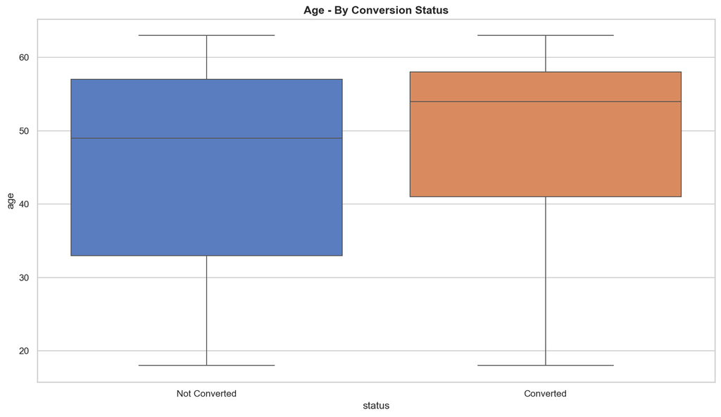

Website Visits

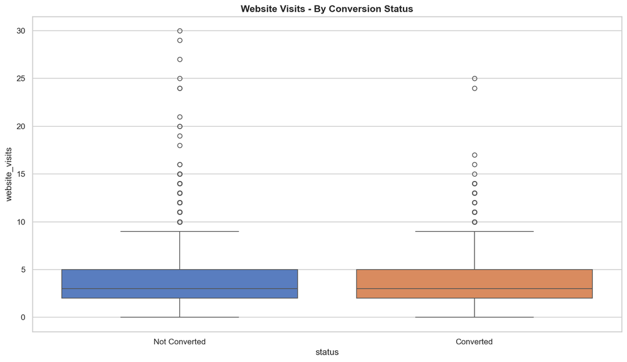

Time Spent On Website

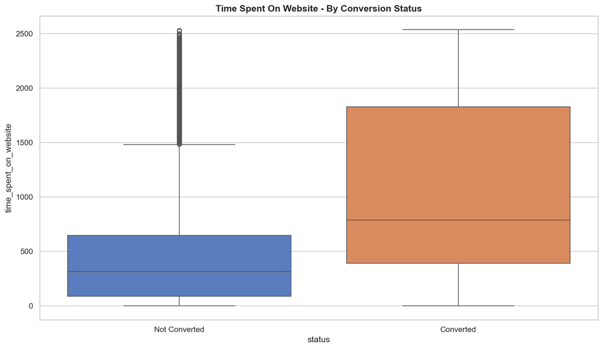

Page Views Per Visit

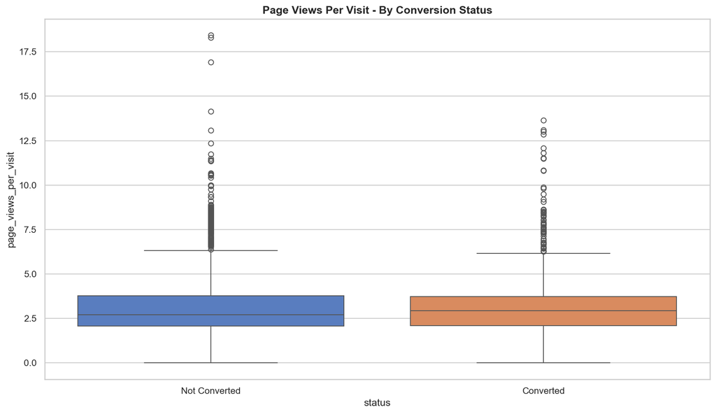

```python
# Loop through each numeric column
for num in num_cols:
    display(Markdown(f'#### {num.replace("_", " ").title()}'))
    boxplot_by_status(data, num)
```

#### Observations

**Age:** Leads that converted tend to fall in a tighter age range, with an IQR between 41 and 58 years old and a median around 54. Non-converted leads show a broader spread, with an IQR between 33 and 57. This suggests that more mature leads have a moderately higher tendency to convert, likely reflecting greater financial stability and career motivation. An interesting future opportunity would be identifying what it takes to get younger leads to convert earlier -- and potentially become repeat buyers -- though that is beyond the scope of this project.

**Website Visits:** Converted and non-converted leads show nearly identical medians and IQR for visit count, meaning visit frequency alone is not a strong signal. However, non-converted leads produced more high-end outliers, with some visiting up to 30 times compared to a max of 25 for converted leads. A lead visiting frequently without converting is an interesting behavioral pattern -- there is enough curiosity to keep returning, but something is preventing the decision to commit. Understanding what triggers that final conversion is a worthwhile question for the sales team.

**Time Spent on Website:** This is the strongest numeric signal in the dataset. Converted leads show a much higher time distribution, with an IQR between roughly 400 and 1800 minutes and a range up to 2,600 minutes. The majority of non-converted leads spent less time on the site than the median converted lead. Time on site reflects genuine engagement with the content, which appears to be a meaningful precursor to conversion.

**Page Views per Visit:** The pattern here closely mirrors website visits -- nearly identical distributions between converted and non-converted leads, with a similar outlier structure. This aligns with the low correlation we saw between these two features and the target in the correlation analysis. Neither metric alone is a strong differentiator, but both may contribute in combination with other features.

**Key Takeaway:** Time spent on the website is the clearest numeric predictor of conversion. Age shows a moderate signal favoring more mature leads. Visit count and page views are weaker on their own but may carry more weight as part of engineered composite features -- something we will explore in preprocessing. The pattern of high-frequency visitors who do not convert is worth flagging for the sales team as a potential re-engagement opportunity.

*Note: The unit of measurement for `time_spent_on_website` is not explicitly defined in the data dictionary. For this analysis it is assumed to represent cumulative time in minutes across all visits per lead. The relative difference between converted and non-converted leads holds regardless of unit interpretation.*

## Preprocessing & Feature Engineering

EDA gave a clear picture of what needs attention before modeling. The steps here run in a logical order -- data quality first, then transformations, then the split.

1. **Missing Values**: none found in the audit, documented here for the record
2. **Outlier Detection & Treatment**: IQR method, cap extreme values rather than drop rows
3. **Skewness & Log Transformation**: post-clipping skewness fell within acceptable bounds -- no log transform needed
4. **Feature Engineering**: composite features to capture engagement patterns not visible in the raw columns
5. **Preprocessing Pipeline**: ColumnTransformer (encoding + scaling)
6. **Train/Test Split**: stratified 70/30 split

### Missing Values

As noted earlier in the Data & Understanding Audit there were no missing values.

### Outlier Detection & Treatment

```python
# Loop through numeric columns: detect via IQR, clip in place if outliers exist
for num in num_cols:
    display(Markdown(f'#### {num.replace("_", " ").title()}'))
    Q1, Q3 = data[num].quantile([0.25, 0.75])
    IQR = Q3 - Q1
    lower, upper = Q1 - 1.5 * IQR, Q3 + 1.5 * IQR
    outliers = ((data[num] < lower) | (data[num] > upper)).sum()
    pct = outliers / len(data) * 100
    print(f'Outliers detected: {outliers}')
    print(f'Lower bound: {lower:.2f} | Upper bound: {upper:.2f}')
    print(f'Outlier percentage: {pct:.2f}%')
    if outliers > 0:
        data[num] = data[num].clip(lower, upper)
        print(f'-> Clipped to IQR bounds')
```

Age

```
Outliers detected: 0
Lower bound: 4.50 | Upper bound: 88.50
Outlier percentage: 0.00%
```

Website Visits

```
Outliers detected: 154
Lower bound: -2.50 | Upper bound: 9.50
Outlier percentage: 3.34%
-> Clipped to IQR bounds
```

Time Spent On Website

```
Outliers detected: 0
Lower bound: -1633.25 | Upper bound: 3118.75
Outlier percentage: 0.00%
```

Page Views Per Visit

```
Outliers detected: 257
Lower bound: -0.44 | Upper bound: 6.27
Outlier percentage: 5.57%
-> Clipped to IQR bounds
```

#### Observations

| Feature | Outliers | % of Data | Upper Bound |
| --- | --- | --- | --- |
| age | 0 | 0.00% | 88.50 |
| website_visits | 154 | 3.34% | 9.50 |
| time_spent_on_website | 0 | 0.00% | 3,118.75 |
| page_views_per_visit | 257 | 5.57% | 6.27 |

`age` and `time_spent_on_website` came back clean. `website_visits` and `page_views_per_visit` both had outliers on the high end.

**Treatment: Clipping (Winsorizing)**

I clipped rather than dropped. Dropping rows means removing real leads -- a lead who visited 30 times isn't a data error, they're a highly engaged prospect and that record has real signal. Capping at the IQR upper bound keeps the record in the dataset while reducing the influence of extreme values on model training. Both features verified clean after treatment.

### Skewness & Log Transformation

```python
# Quantify the skewness of numeric features for potential log transformation
skewness = data[num_cols].skew().round(2)
for num in num_cols:
    print(f'{num}: Skewness = {skewness[num]}')
```

```
age: Skewness = -0.72
website_visits: Skewness = 0.89
time_spent_on_website: Skewness = 0.95
page_views_per_visit: Skewness = 0.2
```

#### Observations

Skewness between -1 and 1 doesn't require log transformation. All four features land within that range after clipping, so no further treatment is needed here.

*Note: Clipping changes real values -- a lead who visited 30 times and one who visited 9 times look the same after capping. For tree-based models this step is largely a non-issue since they handle extreme values naturally. The treatment matters more for Logistic Regression, which is sensitive to scale. Worth keeping in mind when comparing model results.*

### Preprocessing Pipeline

```python
# Encode the yes/no categorical features as 1 or 0 for modeling
binary_cols = ['print_media_type1', 'print_media_type2', 'digital_media', 'educational_channels', 'referral']
for col in binary_cols:
    data[col] = data[col].map({'Yes': 1, 'No': 0})
    print(f'{col} encoded: Yes=1, No=0')

data[binary_cols].head()
```

```
print_media_type1 encoded: Yes=1, No=0
print_media_type2 encoded: Yes=1, No=0
digital_media encoded: Yes=1, No=0
educational_channels encoded: Yes=1, No=0
referral encoded: Yes=1, No=0
```

|  | print_media_type1 | print_media_type2 | digital_media | educational_channels | referral |
| --- | --- | --- | --- | --- | --- |
| 0 | 1 | 0 | 1 | 0 | 0 |
| 1 | 0 | 0 | 0 | 1 | 0 |
| 2 | 0 | 0 | 1 | 0 | 0 |
| 3 | 0 | 0 | 0 | 0 | 0 |
| 4 | 0 | 0 | 0 | 0 | 0 |

```python
# Summarize the total media/marketing touches
media_cols = ['print_media_type1', 'print_media_type2', 'digital_media', 'educational_channels']
data['marketing_touch_count'] = data[media_cols].sum(axis=1)
data.head()
```

|  | ID | age | current_occupation | first_interaction | profile_completed | website_visits | time_spent_on_website | page_views_per_visit | last_activity | print_media_type1 | print_media_type2 | digital_media | educational_channels | referral | status | marketing_touch_count |
| --- | --- | --- | --- | --- | --- | --- | --- | --- | --- | --- | --- | --- | --- | --- | --- | --- |
| 0 | EXT001 | 57 | Unemployed | Website | High | 7.00 | 1639 | 1.86 | Website Activity | 1 | 0 | 1 | 0 | 0 | 1 | 2 |
| 1 | EXT002 | 56 | Professional | Mobile App | Medium | 2.00 | 83 | 0.32 | Website Activity | 0 | 0 | 0 | 1 | 0 | 0 | 1 |
| 2 | EXT003 | 52 | Professional | Website | Medium | 3.00 | 330 | 0.07 | Website Activity | 0 | 0 | 1 | 0 | 0 | 0 | 1 |
| 3 | EXT004 | 53 | Unemployed | Website | High | 4.00 | 464 | 2.06 | Website Activity | 0 | 0 | 0 | 0 | 0 | 1 | 0 |
| 4 | EXT005 | 23 | Student | Website | High | 4.00 | 600 | 6.27 | Email Activity | 0 | 0 | 0 | 0 | 0 | 0 | 0 |

```python
# Create an engagement score from the numeric behavioral features
components = ['website_visits', 'time_spent_on_website', 'page_views_per_visit']
scaled = MinMaxScaler().fit_transform(data[components])
data['engagement_score'] = scaled.sum(axis=1)

data.head()
```

|  | ID | age | current_occupation | first_interaction | profile_completed | website_visits | time_spent_on_website | page_views_per_visit | last_activity | print_media_type1 | print_media_type2 | digital_media | educational_channels | referral | status | marketing_touch_count | engagement_score |
| --- | --- | --- | --- | --- | --- | --- | --- | --- | --- | --- | --- | --- | --- | --- | --- | --- | --- |
| 0 | EXT001 | 57 | Unemployed | Website | High | 7.00 | 1639 | 1.86 | Website Activity | 1 | 0 | 1 | 0 | 0 | 1 | 2 | 1.68 |
| 1 | EXT002 | 56 | Professional | Mobile App | Medium | 2.00 | 83 | 0.32 | Website Activity | 0 | 0 | 0 | 1 | 0 | 0 | 1 | 0.29 |
| 2 | EXT003 | 52 | Professional | Website | Medium | 3.00 | 330 | 0.07 | Website Activity | 0 | 0 | 1 | 0 | 0 | 0 | 1 | 0.46 |
| 3 | EXT004 | 53 | Unemployed | Website | High | 4.00 | 464 | 2.06 | Website Activity | 0 | 0 | 0 | 0 | 0 | 1 | 0 | 0.93 |
| 4 | EXT005 | 23 | Student | Website | High | 4.00 | 600 | 6.27 | Email Activity | 0 | 0 | 0 | 0 | 0 | 0 | 0 | 1.66 |

```python
# Create the high-intent flag
high_completion = data['profile_completed'] == 'High'
high_time_web = data['time_spent_on_website'] > data['time_spent_on_website'].median()

# Flag leads with both signals (High = 1, Low = 0)
data['high_intent_flag'] = (high_completion & high_time_web).astype(int)
display(data.head())

data['high_intent_flag'].value_counts()
```

|  | ID | age | current_occupation | first_interaction | profile_completed | website_visits | time_spent_on_website | page_views_per_visit | last_activity | print_media_type1 | print_media_type2 | digital_media | educational_channels | referral | status | marketing_touch_count | engagement_score | high_intent_flag |
| --- | --- | --- | --- | --- | --- | --- | --- | --- | --- | --- | --- | --- | --- | --- | --- | --- | --- | --- |
| 0 | EXT001 | 57 | Unemployed | Website | High | 7.00 | 1639 | 1.86 | Website Activity | 1 | 0 | 1 | 0 | 0 | 1 | 2 | 1.68 | 1 |
| 1 | EXT002 | 56 | Professional | Mobile App | Medium | 2.00 | 83 | 0.32 | Website Activity | 0 | 0 | 0 | 1 | 0 | 0 | 1 | 0.29 | 0 |
| 2 | EXT003 | 52 | Professional | Website | Medium | 3.00 | 330 | 0.07 | Website Activity | 0 | 0 | 1 | 0 | 0 | 0 | 1 | 0.46 | 0 |
| 3 | EXT004 | 53 | Unemployed | Website | High | 4.00 | 464 | 2.06 | Website Activity | 0 | 0 | 0 | 0 | 0 | 1 | 0 | 0.93 | 1 |
| 4 | EXT005 | 23 | Student | Website | High | 4.00 | 600 | 6.27 | Email Activity | 0 | 0 | 0 | 0 | 0 | 0 | 0 | 1.66 | 1 |

```
high_intent_flag
0    3431
1    1181
Name: count, dtype: int64
```

```python
# Drop ID since it does not add any predictive value
data.drop(columns=['ID'], inplace=True)

# Create variables for training/testing split and modeling pipelines
X = data.drop(columns=['status'])
y = data['status']

X.columns
```

```
Index(['age', 'current_occupation', 'first_interaction', 'profile_completed',
       'website_visits', 'time_spent_on_website', 'page_views_per_visit',
       'last_activity', 'print_media_type1', 'print_media_type2',
       'digital_media', 'educational_channels', 'referral',
       'marketing_touch_count', 'engagement_score', 'high_intent_flag'],
      dtype='str')
```

```python
# Define categorical and numeric features for the preprocessor
cat_features = [
    'current_occupation', 'first_interaction',
    'profile_completed', 'last_activity'
]
num_features = [
    'age', 'website_visits', 'time_spent_on_website', 'page_views_per_visit',
    'marketing_touch_count', 'engagement_score', 'high_intent_flag',
    'print_media_type1', 'print_media_type2', 'digital_media',
    'educational_channels', 'referral'
]

# ColumnTransformer applies different transformations to different column groups
preprocessor = ColumnTransformer(transformers=[
    ('num', StandardScaler(), num_features),
    ('cat', OneHotEncoder(handle_unknown='ignore'), cat_features)
])
```

#### Observations

Three new features were engineered to capture patterns the raw columns don't express on their own:

**Binary Encoding:** The Yes/No media columns were mapped to 1/0 so they could be used in calculations. This was a prerequisite for the next step.

**Engagement Score:** A composite of website visits, time on site, and page views, each normalized to a 0-1 scale before summing. Normalization was necessary because the three features operate on very different scales -- without it, time on site would dominate the score entirely.

**High Intent Flag:** Marks leads with both high profile completion and above-median time on site. 1,181 leads (25.6%) met both criteria. This captures a behavioral profile -- someone who invested time both setting up their profile and exploring the site -- that individual features alone wouldn't surface cleanly.

```python
# Validate that engineered features show signal vs the target
print('Conversion rate by high_intent_flag:')
print(data.groupby('high_intent_flag')['status'].mean().round(3))

print('\nConversion rate by marketing_touch_count:')
print(data.groupby('marketing_touch_count')['status'].mean().round(3))

print('\nEngagement score correlation with status:')
print(data[['engagement_score', 'status']].corr().round(3))
```

```
Conversion rate by high_intent_flag:
high_intent_flag
0   0.22
1   0.54
Name: status, dtype: float64

Conversion rate by marketing_touch_count:
marketing_touch_count
0   0.30
1   0.30
2   0.33
3   0.38
4   0.00
Name: status, dtype: float64

Engagement score correlation with status:
                  engagement_score  status
engagement_score              1.00    0.18
status                        0.18    1.00
```

#### Observations

These features go into the model with confidence.

### Train/Test Split

```python
# Create train/test split
X_train, X_test, y_train, y_test = train_test_split(
    X, y, test_size=0.3, random_state=42, stratify=y
)

# Verify the split
print(f'Training set: {X_train.shape} | Test set: {X_test.shape}')
print(f'Train conversion rate: {y_train.mean():.2%} | Test conversion rate: {y_test.mean():.2%}')
```

```
Training set: (3228, 16) | Test set: (1384, 16)
Train conversion rate: 29.86% | Test conversion rate: 29.84%
```

```python
# Compute sample weights for class imbalance
# Used by Gradient Boosting, which does not support class_weight='balanced' directly
sample_weights = compute_sample_weight(
    class_weight='balanced',
    y=y_train
)
```

#### Observations

The data was split into a 70/30 train/test ratio with stratification applied on the target variable. Both sets maintained the original class distribution -- a 29.86% conversion rate in training and 29.84% in test -- confirming that the class imbalance is proportionally represented in each set. This is important for ensuring the model trains and evaluates on representative data.

## Modeling

With preprocessing complete, the data is ready for modeling. The goal is to build a binary classifier that predicts whether a lead will convert, then identify the best performer through systematic comparison.

Four models are trained in order of complexity:

1. **Logistic Regression**: baseline model, linear and interpretable
2. **Decision Tree**: captures non-linear patterns, easy to visualize
3. **Random Forest**: ensemble of trees, reduces overfitting through averaging
4. **Gradient Boosting**: sequential ensemble, typically the strongest performer on tabular data

Each model is built inside a scikit-learn Pipeline that applies the preprocessing steps (encoding and scaling) automatically before training. This prevents data leakage and keeps the workflow clean and reproducible.

All classifiers use `class_weight='balanced'` to account for the 70/30 class imbalance in the target variable. Without this, a model that predicts "not converted" every time would appear to perform well on accuracy alone.

Model performance is evaluated using metrics suited for imbalanced classification: Precision, Recall, F1-Score, and ROC-AUC. Accuracy is tracked but not used as the primary decision metric.

The best-performing models are tuned further using cross-validated hyperparameter search before final evaluation.

```python
# Helper: render a labelled confusion matrix for any fitted model
def show_confusion(y_true, y_pred, title):
    cm = confusion_matrix(y_true, y_pred)
    disp = ConfusionMatrixDisplay(cm, display_labels=('Not Converted', 'Converted'))
    disp.plot(cmap='Blues')
    plt.title(title)
    disp.ax_.set_xlabel('Predicted')
    disp.ax_.set_ylabel('True')
    plt.show()
```

### Logistic Regression

```
              precision    recall  f1-score   support

           0       0.91      0.79      0.85       971
           1       0.63      0.82      0.71       413

    accuracy                           0.80      1384
   macro avg       0.77      0.81      0.78      1384
weighted avg       0.83      0.80      0.81      1384

ROC-AUC: 0.8779
```

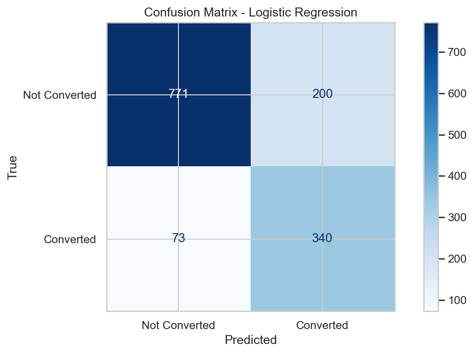

```python
# Logistic Regression baseline (linear, interpretable)
lr_pipe = Pipeline(steps=[
    ('preprocessor', preprocessor),
    ('classifier', LogisticRegression(class_weight='balanced', random_state=42))
])

lr_pipe.fit(X_train, y_train)
y_pred = lr_pipe.predict(X_test)

print(classification_report(y_test, y_pred))
print(f'ROC-AUC: {roc_auc_score(y_test, lr_pipe.predict_proba(X_test)[:, 1]):.4f}')

show_confusion(y_test, y_pred, 'Confusion Matrix - Logistic Regression')
```

#### Observations

Baseline model. Recall (0.82) is the strongest part of the result -- the model catches most actual converters. Precision (0.63) is the tradeoff: about a third of the leads it flags as converters won't actually convert. F1 lands at 0.71 and ROC-AUC at 0.88, both reasonable for a first pass.

For this problem, leaning on recall is the right call. The cost of a false positive is a sales rep making an extra call that doesn't close. The cost of a false negative is missing a real customer entirely.

**Note on class weight:** I used `class_weight='balanced'` because the dataset is ~70/30 against the positive class. Without it, the model would happily predict "not converted" for everything and look fine on accuracy alone.

### Decision Tree

```
              precision    recall  f1-score   support

           0       0.87      0.85      0.86       971
           1       0.67      0.69      0.68       413

    accuracy                           0.81      1384
   macro avg       0.77      0.77      0.77      1384
weighted avg       0.81      0.81      0.81      1384

ROC-AUC: 0.7735
```

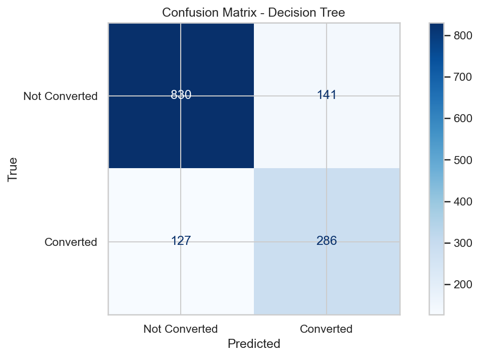

```python
# Decision Tree (captures non-linear splits, easy to inspect)
dt_pipe = Pipeline(steps=[
    ('preprocessor', preprocessor),
    ('classifier', DecisionTreeClassifier(class_weight='balanced', random_state=42))
])

dt_pipe.fit(X_train, y_train)
y_pred = dt_pipe.predict(X_test)

print(classification_report(y_test, y_pred))
print(f'ROC-AUC: {roc_auc_score(y_test, dt_pipe.predict_proba(X_test)[:, 1]):.4f}')

show_confusion(y_test, y_pred, 'Confusion Matrix - Decision Tree')
```

#### Observations

Decision Tree comes in weaker than Logistic Regression on the metrics that matter here. Recall dropped from 0.82 to 0.69, which means more real converters slip through. Precision ticked up slightly (0.67 vs 0.63), but that's a poor trade in this business context. ROC-AUC also fell to 0.77 -- a single tree just doesn't rank leads as well as a calibrated linear model on this data.

Moving on to ensembles to see if averaging across many trees fixes the recall problem without giving up the precision gains.

### Random Forest

```
              precision    recall  f1-score   support

           0       0.88      0.92      0.90       971
           1       0.79      0.70      0.74       413

    accuracy                           0.85      1384
   macro avg       0.83      0.81      0.82      1384
weighted avg       0.85      0.85      0.85      1384

ROC-AUC: 0.9142
```

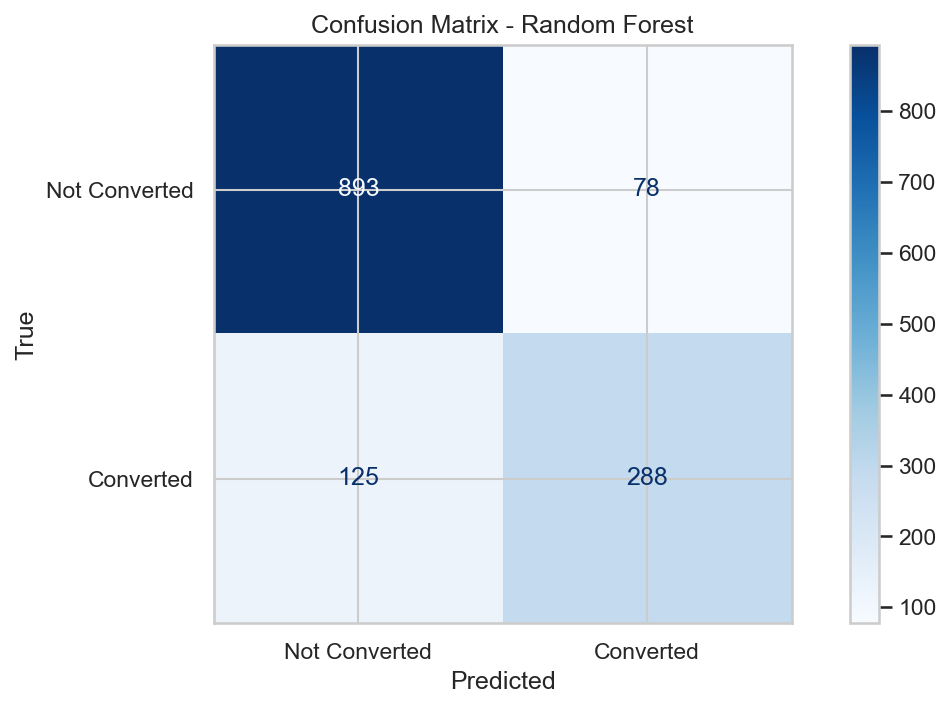

```python
# Random Forest (bagged ensemble of trees)
rf_pipe = Pipeline(steps=[
    ('preprocessor', preprocessor),
    ('classifier', RandomForestClassifier(
        n_estimators=100,
        class_weight='balanced',
        random_state=42
    ))
])

rf_pipe.fit(X_train, y_train)
y_pred = rf_pipe.predict(X_test)

print(classification_report(y_test, y_pred))
print(f'ROC-AUC: {roc_auc_score(y_test, rf_pipe.predict_proba(X_test)[:, 1]):.4f}')

show_confusion(y_test, y_pred, 'Confusion Matrix - Random Forest')
```

#### Observations

Big jump in precision: 0.79, the best so far. Recall sits at 0.70 -- better than the single Decision Tree, still below Logistic Regression's 0.82. ROC-AUC of 0.91 is a clear step up and confirms the ensemble is ranking leads much better than either of the previous models.

The tradeoff is now between Logistic Regression (catch more converters, accept more false positives) and Random Forest (cleaner list, miss a few more). Worth seeing if boosting can deliver both.

### Gradient Boosting (Tuned)

Tuning Gradient Boosting with `GridSearchCV` over learning rate, tree depth, number of estimators, subsample fraction, and min split/leaf size. Five-fold stratified CV keeps the class balance consistent across folds. Goal is to push ROC-AUC higher than the Random Forest baseline without trashing precision.

```
Best Parameters:
{'classifier__learning_rate': 0.01, 'classifier__max_depth': 4, 'classifier__min_samples_leaf': 1, 'classifier__min_samples_split': 10, 'classifier__n_estimators': 500, 'classifier__subsample': 0.9}

Best CV ROC-AUC: 0.9273
              precision    recall  f1-score   support

           0       0.93      0.85      0.89       971
           1       0.71      0.85      0.77       413

    accuracy                           0.85      1384
   macro avg       0.82      0.85      0.83      1384
weighted avg       0.86      0.85      0.85      1384

ROC-AUC: 0.9293
```

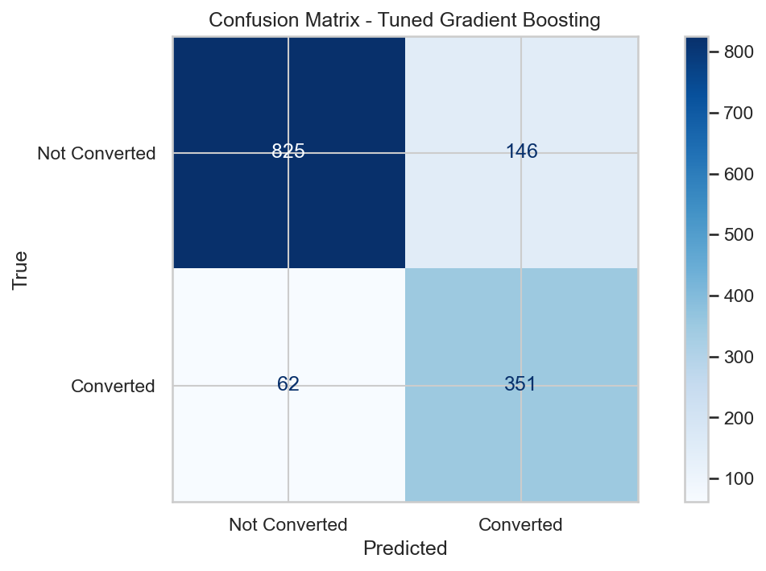

```python
# Tuned Gradient Boosting via GridSearchCV
gb_pipe = Pipeline(steps=[
    ('preprocessor', preprocessor),
    ('classifier', GradientBoostingClassifier(random_state=42))
])

param_grid = {
    'classifier__n_estimators': [100, 200, 300, 500],
    'classifier__learning_rate': [0.01, 0.05, 0.1],
    'classifier__subsample': [0.7, 0.8, 0.9, 1.0],
    'classifier__max_depth': [2, 3, 4],
    'classifier__min_samples_split': [2, 5, 10],
    'classifier__min_samples_leaf': [1, 2, 4]
}

# Stratified CV preserves class balance in each fold
stratified_cv = StratifiedKFold(n_splits=5, shuffle=True, random_state=42)

gb_grid = GridSearchCV(
    estimator=gb_pipe,
    param_grid=param_grid,
    scoring='roc_auc',
    cv=stratified_cv,
    n_jobs=-1
)

gb_grid.fit(X_train, y_train, classifier__sample_weight=sample_weights)

print('Best Parameters:')
print(gb_grid.best_params_)
print(f'\nBest CV ROC-AUC: {gb_grid.best_score_:.4f}')

best_gb_model = gb_grid.best_estimator_
y_pred_gb = best_gb_model.predict(X_test)

print(classification_report(y_test, y_pred_gb))
roc_auc_gb = roc_auc_score(y_test, best_gb_model.predict_proba(X_test)[:, 1])
print(f'ROC-AUC: {roc_auc_gb:.4f}')

show_confusion(y_test, y_pred_gb, 'Confusion Matrix - Tuned Gradient Boosting')
```

#### Observations

Tuned Gradient Boosting hits the sweet spot the earlier models couldn't. Recall climbs back to 0.85 (close to Logistic Regression's 0.82) and precision lands at 0.71 -- not as clean as Random Forest's 0.79, but the recall gain more than makes up for it. F1 of 0.77 and ROC-AUC of 0.93 are both the best results so far.